# sim250 sweep tables

## Table 1. Null GWAS simulation: LD fit

Excess Gaussian LD-fit loss (ridge 0.001) of each single panel over the mixed panel at the generating weight, per SNP; lower is better, and the mixed panel is 0 by definition. Chromosome 22, fixed 250 kb LD blocks. Each setting is a GWAS combining two ancestries' discovery samples at the stated composition; PRS-LDmix uses the matching weight. PRS-CS with automatic φ. Means over replicates with Monte Carlo standard errors in parentheses; within a replicate every method analyses the same simulated GWAS and scores the same target individuals. The seed rerun repeats first-ancestry PRS-CS with a different sampler seed and measures run-to-run variation.

| Pair | GWAS mix | Replicates | LD-fit loss above the generating weight First-ancestry panel | LD-fit loss above the generating weight Second-ancestry panel |
| --- | --- | --- | --- | --- |
| EUR + ASN | 90:10 | 100 | 0.309 (0.003) | 4.414 (0.031) |
|  | 70:30 | 100 | 1.241 (0.009) | 3.261 (0.024) |
|  | 50:50 | 100 | 2.281 (0.016) | 2.215 (0.017) |
| EUR + SAS | 90:10 | 100 | 0.155 (0.003) | 4.728 (0.036) |
|  | 70:30 | 100 | 0.620 (0.012) | 3.896 (0.029) |
|  | 50:50 | 100 | 1.125 (0.020) | 3.104 (0.024) |
| EUR + AFR | 90:10 | 100 | 1.652 (0.023) | 2.655 (0.026) |
|  | 70:30 | 100 | 5.788 (0.075) | 1.975 (0.021) |
|  | 50:50 | 100 | 10.096 (0.127) | 1.466 (0.016) |
| ASN + AFR | 90:10 | 100 | 1.546 (0.026) | 4.149 (0.032) |
|  | 70:30 | 100 | 5.333 (0.080) | 3.111 (0.025) |
|  | 50:50 | 100 | 9.276 (0.135) | 2.228 (0.019) |

## Table 2. Null GWAS simulation: score variance

Variance of target-sample scores in a GWAS with no true effects, relative to first-ancestry PRS-CS for the same GWAS, as a geometric-mean percentage change; negative values mean less spread in scores that carry no true signal. Chromosome 22, fixed 250 kb LD blocks. Each setting is a GWAS combining two ancestries' discovery samples at the stated composition; PRS-LDmix uses the matching weight. PRS-CS with automatic φ. Means over replicates with Monte Carlo standard errors in parentheses; within a replicate every method analyses the same simulated GWAS and scores the same target individuals. The seed rerun repeats first-ancestry PRS-CS with a different sampler seed and measures run-to-run variation.

| Pair | GWAS mix | Targets | Replicates | Null score variance vs. first-ancestry PRS-CS (%) Seed rerun | Null score variance vs. first-ancestry PRS-CS (%) PRS-LDmix | Null score variance vs. first-ancestry PRS-CS (%) Second-ancestry PRS-CS |
| --- | --- | --- | --- | --- | --- | --- |
| EUR + ASN | 90:10 | EUR | 100 | −1.4 (1.5) | −2.3 (1.1) | +13.2 (1.7) |
|  |  | ASN |  | −1.0 (1.5) | −2.9 (1.2) | +4.9 (1.6) |
|  | 70:30 | EUR | 100 | +0.5 (1.6) | −1.4 (1.3) | +10.5 (1.6) |
|  |  | ASN |  | +0.6 (1.6) | −3.9 (1.3) | +2.5 (1.5) |
|  | 50:50 | EUR | 100 | +2.6 (1.5) | −0.8 (1.3) | +5.5 (1.3) |
|  |  | ASN |  | +2.3 (1.5) | −4.6 (1.4) | −3.1 (1.1) |
| EUR + SAS | 90:10 | EUR | 100 | +1.3 (1.4) | +0.7 (1.2) | +10.8 (1.2) |
|  |  | SAS |  | +1.0 (1.6) | +0.2 (1.5) | +7.7 (1.5) |
|  | 70:30 | EUR | 100 | −1.5 (1.3) | −0.2 (1.2) | +3.9 (1.1) |
|  |  | SAS |  | −1.3 (1.6) | −0.6 (1.4) | +2.0 (1.5) |
|  | 50:50 | EUR | 100 | +0.1 (1.7) | −0.6 (1.3) | +4.5 (1.5) |
|  |  | SAS |  | +0.4 (1.9) | −1.6 (1.6) | +1.8 (1.7) |
| EUR + AFR | 90:10 | EUR | 100 | +1.1 (1.5) | −0.4 (1.3) | +26.5 (1.7) |
|  |  | AFR |  | +1.6 (1.9) | −1.2 (1.8) | +15.4 (2.0) |
|  | 70:30 | EUR | 100 | −1.1 (1.6) | −0.4 (1.3) | +15.5 (1.5) |
|  |  | AFR |  | −0.3 (2.0) | −4.2 (1.7) | −0.1 (1.8) |
|  | 50:50 | EUR | 100 | +0.4 (1.5) | +0.9 (1.3) | +10.7 (1.6) |
|  |  | AFR |  | +3.1 (2.2) | −5.4 (1.6) | −4.5 (2.0) |
| ASN + AFR | 90:10 | ASN | 100 | +1.0 (1.5) | +1.4 (1.3) | +28.5 (1.8) |
|  |  | AFR |  | −0.5 (2.2) | −1.2 (2.0) | +9.5 (2.3) |
|  | 70:30 | ASN | 100 | −0.6 (1.5) | −0.4 (1.0) | +16.7 (1.3) |
|  |  | AFR |  | −0.5 (1.9) | −4.4 (1.6) | −1.1 (1.8) |
|  | 50:50 | ASN | 100 | +0.2 (1.7) | −1.0 (1.3) | +10.1 (1.4) |
|  |  | AFR |  | +1.6 (2.3) | −10.1 (1.8) | −8.3 (1.9) |

## Table 3. Non-null GWAS simulation

Sparse causal effects shared across ancestries. Top-10% overlap is the share of target individuals in a method's top score decile who are also in first-ancestry PRS-CS's top decile; *r*<sup>2</sup> is the squared correlation between scores and true genetic values. Chromosome 22, fixed 250 kb LD blocks. Each setting is a GWAS combining two ancestries' discovery samples at the stated composition; PRS-LDmix uses the matching weight. PRS-CS with automatic φ. Means over replicates with Monte Carlo standard errors in parentheses; within a replicate every method analyses the same simulated GWAS and scores the same target individuals. The seed rerun repeats first-ancestry PRS-CS with a different sampler seed and measures run-to-run variation.

| Pair | GWAS mix | Targets | Replicates | Top-10% overlap with first-ancestry PRS-CS (%) Seed rerun | Top-10% overlap with first-ancestry PRS-CS (%) PRS-LDmix | Top-10% overlap with first-ancestry PRS-CS (%) Second-ancestry PRS-CS | *r*<sup>2</sup> with true genetic value First-ancestry PRS-CS | *r*<sup>2</sup> with true genetic value PRS-LDmix | *r*<sup>2</sup> with true genetic value Second-ancestry PRS-CS |
| --- | --- | --- | --- | --- | --- | --- | --- | --- | --- |
| EUR + ASN | 90:10 | EUR | 100 | 91.6 (0.2) | 91.6 (0.2) | 76.0 (0.5) | 0.575 (0.005) | 0.573 (0.005) | 0.497 (0.006) |
|  |  | ASN |  | 90.2 (0.2) | 90.1 (0.2) | 78.3 (0.3) | 0.551 (0.005) | 0.548 (0.005) | 0.486 (0.005) |
|  | 70:30 | EUR | 100 | 91.4 (0.2) | 90.6 (0.2) | 80.5 (0.4) | 0.591 (0.005) | 0.591 (0.005) | 0.550 (0.006) |
|  |  | ASN |  | 90.7 (0.2) | 89.4 (0.2) | 81.6 (0.3) | 0.582 (0.005) | 0.582 (0.005) | 0.549 (0.005) |
|  | 50:50 | EUR | 100 | 91.1 (0.2) | 88.6 (0.2) | 83.1 (0.3) | 0.586 (0.005) | 0.593 (0.005) | 0.579 (0.005) |
|  |  | ASN |  | 91.3 (0.2) | 87.2 (0.4) | 82.5 (0.4) | 0.579 (0.006) | 0.593 (0.005) | 0.581 (0.005) |
| EUR + SAS | 90:10 | EUR | 100 | 91.6 (0.2) | 91.6 (0.1) | 86.8 (0.2) | 0.535 (0.005) | 0.535 (0.005) | 0.516 (0.005) |
|  |  | SAS |  | 88.5 (0.6) | 89.2 (0.6) | 83.8 (0.8) | 0.516 (0.008) | 0.515 (0.008) | 0.489 (0.008) |
|  | 70:30 | EUR | 100 | 92.2 (0.1) | 91.3 (0.1) | 85.2 (0.2) | 0.410 (0.004) | 0.416 (0.004) | 0.413 (0.004) |
|  |  | SAS |  | 90.9 (0.6) | 90.3 (0.7) | 82.2 (0.8) | 0.368 (0.008) | 0.375 (0.008) | 0.371 (0.008) |
|  | 50:50 | EUR | 100 | 94.7 (0.1) | 88.5 (0.1) | 80.1 (0.2) | 0.224 (0.003) | 0.241 (0.003) | 0.246 (0.003) |
|  |  | SAS |  | 94.7 (0.5) | 84.1 (0.8) | 76.1 (0.8) | 0.178 (0.007) | 0.198 (0.007) | 0.203 (0.007) |
| EUR + AFR | 90:10 | EUR | 100 | 91.1 (0.2) | 91.2 (0.2) | 80.6 (0.3) | 0.544 (0.005) | 0.543 (0.005) | 0.492 (0.005) |
|  |  | AFR |  | 87.7 (0.7) | 87.4 (0.7) | 74.5 (1.1) | 0.380 (0.011) | 0.382 (0.011) | 0.346 (0.008) |
|  | 70:30 | EUR | 100 | 91.7 (0.2) | 88.4 (0.3) | 77.6 (0.5) | 0.414 (0.008) | 0.443 (0.006) | 0.442 (0.005) |
|  |  | AFR |  | 92.4 (0.6) | 86.6 (0.8) | 76.0 (1.2) | 0.181 (0.012) | 0.208 (0.012) | 0.231 (0.011) |
|  | 50:50 | EUR | 100 | 94.7 (0.1) | 77.7 (0.4) | 66.4 (0.5) | 0.202 (0.006) | 0.277 (0.005) | 0.302 (0.005) |
|  |  | AFR |  | 97.7 (0.3) | 82.3 (1.1) | 72.3 (1.4) | 0.086 (0.007) | 0.120 (0.008) | 0.143 (0.009) |
| ASN + AFR | 90:10 | ASN | 100 | 91.4 (0.2) | 91.3 (0.2) | 75.6 (0.4) | 0.553 (0.005) | 0.553 (0.005) | 0.471 (0.006) |
|  |  | AFR |  | 88.7 (0.7) | 88.5 (0.7) | 73.3 (1.1) | 0.394 (0.009) | 0.394 (0.009) | 0.342 (0.008) |
|  | 70:30 | ASN | 100 | 92.1 (0.2) | 87.4 (0.3) | 72.4 (0.5) | 0.419 (0.008) | 0.453 (0.006) | 0.441 (0.005) |
|  |  | AFR |  | 93.9 (0.6) | 88.0 (0.9) | 76.7 (1.4) | 0.198 (0.010) | 0.229 (0.010) | 0.245 (0.009) |
|  | 50:50 | ASN | 100 | 94.5 (0.1) | 76.5 (0.4) | 62.7 (0.4) | 0.211 (0.006) | 0.289 (0.005) | 0.318 (0.005) |
|  |  | AFR |  | 97.3 (0.4) | 83.3 (1.2) | 75.1 (1.6) | 0.111 (0.008) | 0.143 (0.009) | 0.165 (0.009) |

## Table 4. PRS-LDmix against the seed rerun and the single panels

Replicate-paired comparisons at the generating weight. Overlap and correlation are differences from the seed rerun (both first measured against first-ancestry PRS-CS); negative values mean PRS-LDmix changes scores more than a new sampler seed alone. Null score variance is PRS-LDmix relative to the seed rerun (geometric-mean percentage change). The last two columns are PRS-LDmix's *r*<sup>2</sup> minus single-panel PRS-CS's; positive values favour PRS-LDmix. pp, percentage points. Chromosome 22, fixed 250 kb LD blocks. Each setting is a GWAS combining two ancestries' discovery samples at the stated composition; PRS-LDmix uses the matching weight. PRS-CS with automatic φ. Means over replicates with Monte Carlo standard errors in parentheses; within a replicate every method analyses the same simulated GWAS and scores the same target individuals. The seed rerun repeats first-ancestry PRS-CS with a different sampler seed and measures run-to-run variation.

| Pair | GWAS mix | Targets | Replicates | PRS-LDmix vs. seed rerun Top-10% overlap (pp) | PRS-LDmix vs. seed rerun Correlation ×10<sup>3</sup> | PRS-LDmix vs. seed rerun Null score variance (%) | PRS-LDmix minus single-panel PRS-CS (*r*<sup>2</sup>) First ancestry | PRS-LDmix minus single-panel PRS-CS (*r*<sup>2</sup>) Second ancestry |
| --- | --- | --- | --- | --- | --- | --- | --- | --- |
| EUR + ASN | 90:10 | EUR | 100 | +0.02 (0.10) | 0.00 (0.06) | −0.9 (1.4) | −0.0011 (0.0007) | +0.0768 (0.0037) |
|  |  | ASN |  | −0.09 (0.13) | −0.14 (0.12) | −1.9 (1.4) | −0.0031 (0.0009) | +0.0629 (0.0023) |
|  | 70:30 | EUR | 100 | −0.71 (0.11) | −1.29 (0.10) | −1.8 (1.5) | +0.0003 (0.0010) | +0.0412 (0.0028) |
|  |  | ASN |  | −1.30 (0.17) | −2.11 (0.20) | −4.4 (1.5) | −0.0004 (0.0012) | +0.0323 (0.0018) |
|  | 50:50 | EUR | 100 | −2.58 (0.15) | −5.52 (0.26) | −3.3 (1.4) | +0.0073 (0.0013) | +0.0141 (0.0018) |
|  |  | ASN |  | −4.15 (0.40) | −10.10 (1.08) | −6.7 (1.4) | +0.0138 (0.0029) | +0.0120 (0.0014) |
| EUR + SAS | 90:10 | EUR | 100 | +0.01 (0.11) | −0.05 (0.09) | −0.7 (1.5) | −0.0003 (0.0006) | +0.0192 (0.0014) |
|  |  | SAS |  | +0.69 (0.65) | −0.14 (0.21) | −0.8 (1.7) | −0.0017 (0.0015) | +0.0253 (0.0024) |
|  | 70:30 | EUR | 100 | −0.87 (0.09) | −1.57 (0.07) | +1.3 (1.3) | +0.0055 (0.0006) | +0.0024 (0.0009) |
|  |  | SAS |  | −0.62 (0.63) | −2.64 (0.17) | +0.8 (1.4) | +0.0076 (0.0014) | +0.0044 (0.0017) |
|  | 50:50 | EUR | 100 | −6.25 (0.13) | −11.41 (0.14) | −0.8 (1.6) | +0.0172 (0.0005) | −0.0047 (0.0005) |
|  |  | SAS |  | −10.62 (0.80) | −18.43 (0.51) | −2.0 (1.8) | +0.0206 (0.0015) | −0.0044 (0.0013) |
| EUR + AFR | 90:10 | EUR | 100 | +0.07 (0.11) | −0.10 (0.09) | −1.4 (1.4) | −0.0008 (0.0007) | +0.0509 (0.0028) |
|  |  | AFR |  | −0.24 (0.62) | −0.52 (0.25) | −2.7 (1.9) | +0.0013 (0.0018) | +0.0360 (0.0050) |
|  | 70:30 | EUR | 100 | −3.34 (0.33) | −8.07 (0.91) | +0.7 (1.5) | +0.0290 (0.0023) | +0.0012 (0.0028) |
|  |  | AFR |  | −5.86 (0.69) | −6.25 (0.49) | −3.9 (1.7) | +0.0276 (0.0015) | −0.0230 (0.0028) |
|  | 50:50 | EUR | 100 | −17.04 (0.47) | −54.10 (2.31) | +0.5 (1.5) | +0.0750 (0.0021) | −0.0249 (0.0014) |
|  |  | AFR |  | −15.43 (1.01) | −24.08 (2.65) | −8.3 (1.8) | +0.0343 (0.0030) | −0.0230 (0.0014) |
| ASN + AFR | 90:10 | ASN | 100 | −0.05 (0.14) | −0.09 (0.07) | +0.4 (1.6) | +0.0002 (0.0006) | +0.0820 (0.0035) |
|  |  | AFR |  | −0.24 (0.55) | −0.29 (0.26) | −0.6 (2.2) | +0.0005 (0.0019) | +0.0526 (0.0051) |
|  | 70:30 | ASN | 100 | −4.72 (0.38) | −10.24 (0.89) | +0.2 (1.6) | +0.0343 (0.0023) | +0.0119 (0.0037) |
|  |  | AFR |  | −5.81 (0.70) | −6.72 (0.54) | −4.0 (1.9) | +0.0309 (0.0015) | −0.0164 (0.0030) |
|  | 50:50 | ASN | 100 | −18.00 (0.42) | −55.25 (1.64) | −1.2 (1.5) | +0.0781 (0.0015) | −0.0289 (0.0018) |
|  |  | AFR |  | −13.95 (1.01) | −21.50 (2.47) | −11.5 (1.7) | +0.0326 (0.0023) | −0.0215 (0.0013) |

## Figure. Per-replicate differences across the sweep

Each point is one replicate (simulated GWAS), with a violin for the distribution and a box for the median and quartiles; dashed line at zero. **a**, PRS-LDmix minus the seed rerun in top-10% overlap with first-ancestry PRS-CS (negative: PRS-LDmix changes the top decile more than a new sampler seed). **b**, PRS-LDmix minus first-ancestry PRS-CS in *r*<sup>2</sup> with the true genetic value (positive: PRS-LDmix more accurate). At most 100 replicates per setting (see the tables for each count).

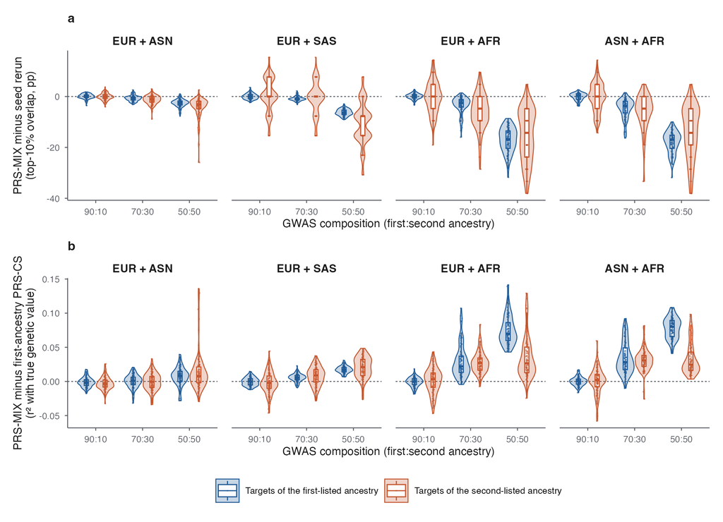